# Cell-type perturbation in MASH vs healthy liver

# Resolving the signature

## Is the hepatocyte response zonal?

Hepatocytes split into pericentral, periportal and interzonal, and the analysis so far appears to say the pericentral zone is most perturbed. However, that reading does not survive scrutiny as the zones differ in donor coverage and in cell numbers, so they differ in power before any biology is considered.

```r
z <- c("Hepatocyte_pericentral", "Hepatocyte_periportal", "Hepatocyte_interzonal")
lab <- c("PC", "PP", "IZ")
cz <- Reduce(intersect, lapply(de_fine[z], function(r) r$gene))
fz <- sapply(de_fine[z], function(r) r$log2FoldChange[match(cz, r$gene)])
az <- sapply(de_fine[z], function(r) r$padj[match(cz, r$gene)])
colnames(fz) <- colnames(az) <- lab
sigz <- !is.na(az) & az < FDR_CUTOFF & abs(fz) >= LFC_CUTOFF
shared <- rowSums(sigz) == 3
concordant <- sum(abs(rowSums(sign(fz[shared, ]))) == 3, na.rm = TRUE)

# Donors contributing a testable pseudo-sample, counted the same way the DE did.
zone_donors <- sapply(z, function(x) {
  k <- md[[COL_CT_FINE]] == x
  n <- table(md[[COL_DONOR]][k])
  d <- unique(md[, c(COL_DONOR, "condition")])
  d <- d[match(names(n), d[[COL_DONOR]]), ]
  ok <- n >= MIN_CELLS & !is.na(d$condition)
  paste(sum(ok & d$condition == "Control"), "/", sum(ok & d$condition == "MASH"))
})

kable(data.frame(
  Zone = lab,
  `Donors (Control / MASH)` = zone_donors,
  `Nuclei` = format(sapply(z, function(x) sum(md[[COL_CT_FINE]] == x)), big.mark = ","),
  `DEGs` = sapply(z, function(x) sum(is_de(de_fine[[x]]))),
  `Median |log2FC|` = round(apply(abs(fz), 2, median, na.rm = TRUE), 3),
  check.names = FALSE), row.names = FALSE,
  caption = "Hepatocyte zones: differential expression against available power.")
```

Hepatocyte zones: differential expression against available power.

| Zone | Donors (Control / MASH) | Nuclei | DEGs | Median \|log2FC\| |
| --- | --- | --- | --- | --- |
| PC | 23 / 18 | 48,614 | 5070 | 0.294 |
| PP | 23 / 16 | 37,872 | 3707 | 0.291 |
| IZ | 23 / 12 | 11,811 | 2502 | 0.318 |

The DEG counts track donor and nucleus numbers, not effect size. Median absolute fold change is essentially identical across the three zones (0.29, 0.29, 0.32), and the pairwise correlation of fold changes between zones is 0.82 to 0.86.

Of the 1,824 genes significant in all three zones, 1,824 agree in direction. That is 100%.

**Hepatocytes mount one disease program, not three zonal ones.** This matters for how the result is used. If the response were zone-restricted, any intervention would have to reach the right zone to be effective. It is not: zonal identity is preserved as a baseline, and the MASH response is superimposed on all three compartments in the same direction and at the same magnitude.

## Module-level structure

Individual genes are a difficult unit to act on. The source study built co-expression modules with hdWGCNA and deposited both the module definitions and per-cell harmonized module eigengenes. Those are reused here rather than recomputed, but tested at the donor level, which their own analysis did not do.

```r
mod_res <- cached("module_de.rds", {
  dirp <- "data/unzipped/Zenodo/hdWGCNA_results"
  meta <- readRDS(cache_path("meta.rds"))
  meta$cond <- unname(CONDITION_MAP[meta[[COL_STAGE]]])
  do.call(rbind, lapply(c("hepatocyte","stellate_cell","endothelial_cell","cholangiocyte"),
    function(tag) {
      x <- read.delim(gzfile(file.path(dirp, paste0(tag, "_hME.txt.gz"))), check.names = FALSE)
      rownames(x) <- x[[1]]; x <- x[, -1, drop = FALSE]
      x <- x[, colnames(x) != "grey", drop = FALSE]
      cm <- intersect(rownames(x), rownames(meta))
      x <- x[cm, , drop = FALSE]; mm <- meta[cm, ]
      dmean <- t(sapply(colnames(x), function(k)
        tapply(x[[k]], mm[[COL_DONOR]], mean, na.rm = TRUE)))
      dn <- unique(mm[, c(COL_DONOR, "cond")]); rownames(dn) <- dn[[COL_DONOR]]
      dn <- dn[colnames(dmean), ]; kp <- !is.na(dn$cond)
      r <- do.call(rbind, lapply(rownames(dmean), function(k) {
        tt <- t.test(dmean[k, kp] ~ factor(dn$cond[kp], levels = CONDITION_LEVELS))
        data.frame(cell_type = tag, module = k,
                   diff = unname(tt$estimate[2] - tt$estimate[1]), p = tt$p.value)
      }))
      r$FDR <- p.adjust(r$p, "BH"); r
    }))
})

sig_mod <- subset(mod_res, FDR < 0.05)
sig_mod <- sig_mod[order(sig_mod$FDR), ]
kable(data.frame(
  `Cell type` = sig_mod$cell_type, Module = sig_mod$module,
  `Change in MASH` = round(sig_mod$diff, 2), FDR = signif(sig_mod$FDR, 2),
  check.names = FALSE), row.names = FALSE,
  caption = "Co-expression modules differentially expressed between MASH and Control, tested on per-donor mean module eigengenes.")
```

Co-expression modules differentially expressed between MASH and Control, tested on per-donor mean module eigengenes.

| Cell type | Module | Change in MASH | FDR |
| --- | --- | --- | --- |
| hepatocyte | Hep-M12 | -2.38 | 0.0e+00 |
| endothelial_cell | endo-M9 | 1.45 | 3.0e-07 |
| endothelial_cell | endo-M7 | 1.16 | 8.0e-07 |
| hepatocyte | Hep-M16 | 1.29 | 1.2e-06 |
| hepatocyte | Hep-M6 | 1.34 | 1.7e-05 |
| hepatocyte | Hep-M1 | 0.45 | 2.1e-05 |
| endothelial_cell | endo-M3 | 0.45 | 4.2e-05 |
| endothelial_cell | endo-M4 | 0.84 | 5.1e-05 |
| endothelial_cell | endo-M8 | 1.54 | 1.0e-03 |
| stellate_cell | HSC-M3 | 2.87 | 4.2e-03 |
| endothelial_cell | endo-M2 | 0.37 | 4.8e-03 |
| hepatocyte | Hep-M11 | 0.45 | 5.3e-03 |
| hepatocyte | Hep-M14 | -0.59 | 5.3e-03 |
| hepatocyte | Hep-M15 | 0.42 | 1.6e-02 |
| hepatocyte | Hep-M7 | 0.27 | 2.2e-02 |
| cholangiocyte | Chol-M7 | 3.91 | 4.5e-02 |

16 of 37 deposited modules move significantly at donor level. The distribution matches the gene-level results closely: 6 of nine endothelial modules shift despite endothelial cells not changing in abundance at all, which is the same dissociation reported earlier arriving through an independent construction.

The largest hepatocyte effect is **Hep-M12**, down by 2.38 (FDR 4.9e-08). Its highest-connectivity members are *FGB*, *FGG*, *FGA*, *FGL1*, *CP*, *CYP3A5* and *PCK1*: fibrinogen synthesis, copper transport, drug metabolism and gluconeogenesis. It is a hepatocyte secretory and metabolic identity program, and it is the single most-perturbed coordinated unit found anywhere in this analysis.

Two further observations: The upregulated hepatocyte module Hep-M6 contains *PPARA*, *MLXIPL* and *PLIN5*, and the upregulated stellate module HSC-M3 contains *NR1H4*. Both are nuclear receptors with existing pharmacology in metabolic liver disease, which is a reassuring sign that the signature is not disconnected from known biology. Nothing here directly tests any drug, and no directional inference about a therapeutic effect follows from a module changing.

# Discussion

## What this dataset can and cannot say about MASH therapeutics

MASH now has FDA approved drugs and a crowded development pipeline, and a natural question is whether a dataset like this speaks to any of them. It does, but only in a specific and limited way.

An observational cross-sectional cohort of 48 donors can establish two things about a drug target: whether the target is expressed in the cell type the drug is meant to act on, and whether the program that target controls is among the things disease has perturbed. Those are questions about whether a mechanism is *engageable* and *relevant* in human MASH liver.

With that stated, the dataset does separate the pipeline into three groups.

```r
drug_expr <- cached("drug_target_expr.rds", {
  library(BPCells)
  mt <- open_matrix_dir("bpcells_counts")
  meta <- readRDS(cache_path("meta.rds"))
  k <- !meta[[COL_CT_BROAD]] %in% DROP_LABELS
  ctf <- factor(as.character(meta[[COL_CT_BROAD]])[k]); sb <- mt[, which(k)]
  nmz <- log1p(multiply_cols(sb, 1e4 / colSums(sb)))
  gg <- c("THRB","DIO1","GLP1R","GCGR","GIPR","KLB","FGFR1","NR1H4","NR0B2",
          "PPARA","PPARD","PPARG","ITGAV","ITGB1","ITGB6","ITGB8",
          "TGFB1","TGFBR1","TGFBR2","LOXL2","LOX","LOXL1")
  present <- gg[gg %in% rownames(mt)]
  a <- pseudobulk_matrix(nmz[present, ], cell_groups = ctf, method = "mean")
  n <- pseudobulk_matrix(sb[present, ],  cell_groups = ctf, method = "nonzeros")
  list(avg = a, pct = sweep(n, 2, as.integer(table(ctf)), "/") * 100,
       absent = setdiff(gg, present))
})

targ <- data.frame(
  Target = c("THRB", "GCGR", "GLP1R", "GIPR", "KLB", "NR1H4", "PPARA", "PPARD",
             "PPARG", "ITGAV", "ITGB6", "TGFB1", "LOXL2", "LOX"),
  Drug = c("resmetirom", "survodutide (glucagon arm)", "semaglutide",
           "tirzepatide (GIP arm)", "FGF21 analogues", "FXR agonists",
           "elafibranor, lanifibranor", "seladelpar, elafibranor",
           "lanifibranor", "integrin inhibitors", "integrin avb6 inhibitors",
           "TGF-beta blockade", "simtuzumab", "LOX inhibitors"),
  stringsAsFactors = FALSE)

look <- function(g, what) {
  if (g %in% drug_expr$absent) return(NA_real_)
  m <- drug_expr[[what]]
  if (!g %in% rownames(m)) return(NA_real_)
  max(m[g, ])
}
where <- function(g) {
  if (g %in% drug_expr$absent) return("not in object")
  colnames(drug_expr$avg)[which.max(drug_expr$avg[g, ])]
}
targ$`Highest in`  <- sapply(targ$Target, where)
targ$`Mean expr`   <- round(sapply(targ$Target, look, "avg"), 2)
targ$`% expressing`<- round(sapply(targ$Target, look, "pct"), 1)
kable(targ, row.names = FALSE,
      caption = "Where each target is expressed. Mean expression and percent are for the cell type where the target is highest.")
```

Where each target is expressed. Mean expression and percent are for the cell type where the target is highest.

| Target | Drug | Highest in | Mean expr | % expressing |
| --- | --- | --- | --- | --- |
| THRB | resmetirom | Hepatocyte | 1.93 | 88.6 |
| GCGR | survodutide (glucagon arm) | Hepatocyte | 0.65 | 47.7 |
| GLP1R | semaglutide | not in object | NA | NA |
| GIPR | tirzepatide (GIP arm) | DC | 0.12 | 8.1 |
| KLB | FGF21 analogues | Hepatocyte | 0.23 | 18.2 |
| NR1H4 | FXR agonists | Stellate_cell | 2.56 | 88.0 |
| PPARA | elafibranor, lanifibranor | Hepatocyte | 1.35 | 75.4 |
| PPARD | seladelpar, elafibranor | DC | 0.26 | 17.4 |
| PPARG | lanifibranor | Macrophage | 0.94 | 45.7 |
| ITGAV | integrin inhibitors | Cholangiocyte | 0.65 | 35.7 |
| ITGB6 | integrin avb6 inhibitors | Cholangiocyte | 0.01 | 0.7 |
| TGFB1 | TGF-beta blockade | NK | 0.63 | 30.6 |
| LOXL2 | simtuzumab | Stellate_cell | 0.13 | 7.5 |
| LOX | LOX inhibitors | Stellate_cell | 0.00 | 0.2 |

### Targets that are well represented in this tissue

**THR-beta (resmetirom).** *THRB* is expressed in 88.6% of hepatocytes, the highest of any cell type, and it is not itself altered in disease. The programs it regulates are hepatocyte fatty acid metabolism, bile acid metabolism and xenobiotic metabolism are all significantly depleted in MASH here, and that loss of differentiated metabolic function is the dominant hepatocyte finding in this report. So the receptor is abundant and intact in exactly the cell type whose metabolic program has degraded. That is a coherent target-tissue picture, and it is the most straightforwardly supported mechanism in the dataset.

**FXR (obeticholic acid and successors).** *NR1H4* is well expressed in both hepatocytes and stellate cells. More informative than the receptor is its output: *NR0B2*, the canonical FXR target gene, is strongly reduced in hepatocytes (log2FC -1.48, FDR 7.7e-10), alongside the depleted bile acid program. FXR signalling output is measurably lower in MASH hepatocytes in this cohort. Whether restoring it is beneficial is a clinical question this dataset cannot address, and the mixed clinical history of FXR agonism is a reminder that pathway restoration and patient benefit are different things.

**Glucagon (survodutide’s glucagon arm).** This one differs, and the distinction is worth drawing. *GCGR* is expressed in 47.7% of hepatocytes and is modestly reduced in MASH (log2FC -0.36, FDR 0.0096). Unlike the GLP-1 and GIP components, the glucagon arm of a dual agonist has a direct hepatocyte target that is measurable in this tissue. That makes glucagon-containing dual agonists the incretin-class agents this dataset can actually say something about.

### Targets whose liver action is not visible in this dataset

**GLP-1 (semaglutide).** *GLP1R* is not present in the object at all. This is not a detection failure peculiar to this study: hepatocytes are not generally held to express GLP-1 receptor, and the hepatic benefit of GLP-1 agonism is understood to be largely indirect, through weight loss, glycaemic control and adipose signalling. The consequence is simply that a liver transcriptomic atlas is the wrong instrument for evaluating it. Its absence here is uninformative about the drug.

**GIP (tirzepatide’s GIP arm).** *GIPR* is effectively undetected in hepatocytes. The same reasoning applies.

**FGF21 analogues.** The obligate co-receptor *KLB* is detected in only 18.2% of hepatocytes, and *FGFR1* is essentially absent from hepatocytes while being present on stellate cells. FGF21 biology is substantially adipose-directed, so a liver dataset again under-reports the mechanism.

### Anti-fibrotic targets: this dataset cannot evaluate them

```r
af <- c("LOX", "LOXL1", "LOXL2", "ITGB6", "ITGB1", "ITGAV", "TGFB1", "TGFBR1", "TGFBR2")
af <- af[!af %in% drug_expr$absent]
kable(data.frame(
  Target = af,
  `Highest in` = sapply(af, where),
  `Mean expr` = round(sapply(af, look, "avg"), 2),
  `% expressing` = round(sapply(af, look, "pct"), 1),
  check.names = FALSE), row.names = FALSE,
  caption = "Anti-fibrotic drug targets, at the cell type where each is highest.")
```

Anti-fibrotic drug targets, at the cell type where each is highest.

| Target | Highest in | Mean expr | % expressing |
| --- | --- | --- | --- |
| LOX | Stellate_cell | 0.00 | 0.2 |
| LOXL1 | Stellate_cell | 0.06 | 3.4 |
| LOXL2 | Stellate_cell | 0.13 | 7.5 |
| ITGB6 | Cholangiocyte | 0.01 | 0.7 |
| ITGB1 | Cholangiocyte | 0.84 | 48.2 |
| ITGAV | Cholangiocyte | 0.65 | 35.7 |
| TGFB1 | NK | 0.63 | 30.6 |
| TGFBR1 | NK | 0.72 | 34.4 |
| TGFBR2 | Endothelial_cell | 1.63 | 71.6 |

The lysyl oxidases are the clearest case. *LOX* is essentially undetected, *LOXL1* and *LOXL2* are detected in a few percent of stellate cells, and *LOXL2* does not change significantly with disease. *ITGB6*, the target of alpha-v-beta-6 integrin inhibition, is effectively absent. *TGFB1* is low in every cell type, and the TGF-beta signalling program is not significantly enriched in stellate cells. Read naively, this would look like a dataset arguing against anti-fibrotic targets.

That reading would be wrong, and the reason is documented earlier in this report. These drugs act on collagen-producing myofibroblasts, and this dataset does not contain them: the highest *COL1A1* count in any nucleus across the entire atlas is 25, and the scar-associated endothelial and mesenchymal populations from the reference cirrhosis atlas both fail to appear while the scar-associated macrophage population replicates cleanly. The most likely explanation for all of it is that needle-core biopsy tissue does not recover cells resident in dense scar matrix.

So the correct statement is not that this dataset provides weak support for anti-fibrotic mechanisms. It is that **this dataset cannot assess them**, because the cell population those drugs target is missing from it for reasons of tissue sampling rather than biology. An apparent absence of a drug target is only evidence when the cells that would express it were recoverable in the first place. The one anti-fibrotic-adjacent target that does move is *ITGAV* in stellate cells (log2FC 0.42, FDR 0.0013), which is suggestive and no more.

### Does the data support combination therapy?

Not directly, and any dataset of this design would struggle to. What it does provide is a structural argument, which is weaker but not empty.

The central result of this report is that MASH perturbation is distributed across cell types along two independent axes, and that the axes do not coincide. Hepatocytes lose a metabolic program and are depleted. Macrophages switch identity from resident Kupffer to scar-associated without much change in number. Endothelial cells carry the second-largest expression program in the dataset with no abundance change at all, and its content is inflammatory. Lymphocytes expand several-fold with comparatively little transcriptional change.

What this dataset cannot do is tell you which second agent to employ. Adjudicating a metabolic-plus-anti-fibrotic combination specifically would require measuring the fibrotic compartment, and this tissue preparation does not recover it (but at least we now know that). A study built on precision-cut liver slices (like the kind I’ve done in the past at Pliant), resections or explants, where myofibroblasts and the scar-resident niche are retained, is the design that could potentially answer the direct anti-fibrotic question.

## Limitations

**Compositional dependence.** Proportions sum to one, so the loss of half the hepatocyte compartment mechanically inflates every other fraction. The immune expansions are relative enrichments. Distinguishing that from absolute infiltration would require a cell-number-per-unit-tissue measurement that dissociation-based data cannot provide.

**No batch variable.** The deposit carries no sequencing run, chemistry or processing-date column, so no technical covariate could be tested or adjusted for. The cohort is single-center, which limits the risk, but this cannot be verified from what was deposited.

**Fibrosis is available only as a dichotomy.** The source study staged fibrosis on the full Brunt/Kleiner F0-F4 scale, but used it only to define the eMASH (F0-2) and aMASH (F3-4) groups, and the per-donor stage was not deposited. The metadata carries disease group and nothing else clinical: no fibrosis stage, no activity score, no ALT, and no age, sex or BMI. The finest fibrosis comparison possible here is therefore the two-bin eMASH-versus-aMASH contrast, on 9 and 10 donors. No dose-response across F0 to F4 can be tested, and the stellate result above should be read with that in mind: it is a difference between two coarse fibrosis bins, not a gradient. The same constraint rules out relating cell-type proportions to clinical severity, which the source paper was able to do because it had the clinical table.

**Controls are not healthy volunteers.** They are biopsies from people undergoing clinical procedures with no MASLD diagnosis. A baseline of stellate activation and immune presence is expected, and comparisons are against that baseline, not against normal liver.

**Unequal and modest group sizes.** The stage-resolved contrasts rest on 6 to 10 donors per arm. The eMASH-versus-aMASH stellate result does not survive multiple-testing correction and is reported as suggestive for that reason.

**Reused integration and inherited annotation.** The analysis relies on the deposited Liger integration and cluster labels rather than re-deriving them. That is deliberate: the labels were validated against canonical markers before use, and re-clustering a published, already-integrated object risks recapitulating the original result rather than testing it. It does mean any error in the deposited annotation propagates here, as the stellate `inactivated` subcluster illustrates. That case also shows the check working: the mixture was detectable from marker expression, from unbiased enrichment and from the subcluster-level profile, without re-clustering anything.

# Supplementary

## Within-lineage resolution

Two lineages subdivide in the deposited annotation, and both subdivide along an axis MASH acts on. This is where the detailed labels earn their place.

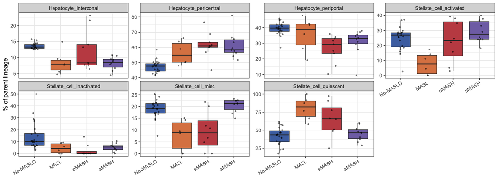

```r
sub_frac <- function(prefix) {
  s  <- md[grepl(prefix, md[[COL_CT_FINE]]), ]
  tb <- table(s[[COL_DONOR]], s[[COL_CT_FINE]])
  pr <- sweep(tb, 1, rowSums(tb), "/") * 100
  st <- donors$stage[match(rownames(pr), donors$donor)]
  data.frame(donor = rep(rownames(pr), ncol(pr)),
             subtype = rep(colnames(pr), each = nrow(pr)),
             pct = as.vector(pr), stage = rep(st, ncol(pr)))
}

st_frac  <- sub_frac("^Stellate")
hep_frac <- sub_frac("^Hepatocyte")

ggplot(rbind(st_frac, hep_frac), aes(stage, pct, fill = stage)) +
  geom_boxplot(outlier.shape = NA, linewidth = 0.3) +
  geom_jitter(width = 0.15, size = 0.6, alpha = 0.5) +
  facet_wrap(~ subtype, nrow = 2, scales = "free_y") +
  scale_fill_manual(values = c("#4C72B0", "#DD8452", "#C44E52", "#8172B3")) +
  labs(x = NULL, y = "% of parent lineage") +
  theme_bw(base_size = 9) +
  theme(legend.position = "none",
        axis.text.x = element_text(angle = 30, hjust = 1))
```

```r
sm <- function(d) round(sapply(levels(donors$stage), function(s)
  tapply(d$pct[d$stage == s], d$subtype[d$stage == s], mean, na.rm = TRUE)), 1)
kable(rbind(sm(st_frac), sm(hep_frac)),
      caption = "Mean composition within each lineage (%), by stage.")
```

Mean composition within each lineage (%), by stage.

|  | No-MASLD | MASL | eMASH | aMASH |
| --- | --- | --- | --- | --- |
| Stellate_cell_activated | 24.5 | 7.7 | 22.7 | 29.1 |
| Stellate_cell_inactivated | 14.3 | 4.5 | 2.6 | 5.1 |
| Stellate_cell_misc | 18.9 | 7.9 | 9.5 | 20.4 |
| Stellate_cell_quiescent | 42.3 | 79.9 | 65.2 | 45.4 |
| Hepatocyte_interzonal | 13.5 | 8.4 | 12.2 | 8.2 |
| Hepatocyte_pericentral | 47.1 | 56.1 | 61.4 | 61.2 |
| Hepatocyte_periportal | 39.4 | 35.5 | 26.4 | 30.6 |

Hepatocyte zonation shifts consistently: the pericentral fraction rises across the progression while periportal and interzonal fractions fall. Given that hepatocytes are simultaneously halving in absolute proportion, this is a relative change in which zonal identity survives, not evidence that pericentral hepatocytes increase in number.

The stellate substates move much less than their names suggest. The activated fraction is already 24.5% in controls and reaches only 29.1% in advanced MASH. The controls are liver biopsies from people undergoing clinical procedures rather than healthy volunteers, so a non-trivial baseline of stellate activation is plausible.

The substate that does move sharply is `inactivated`, which falls from 14.3% to 5.1%. That turns out to matter more than the activated fraction, and it is taken up in detail below, after the enrichment results supply a second line of evidence about what that subcluster actually contains.

How these substate labels were produced is relevant to reading them. The source paper’s supplementary methods describe subclustering all donors together, then subclustering disease and control cells separately, and assigning a substate only where both analyses agreed. Cells that disagreed were labeled `Unidentified`, and subclusters showing ectopic marker expression were labeled `misc`. That is a conservative procedure, but it means the substate assignments are not independent of disease status, so substate proportions compared across disease groups should be read as descriptive rather than as a clean test.

## Is this a technical gradient?

Enrichment on pseudobulk is vulnerable to a specific failure: proliferation and biosynthesis sets are loaded with highly expressed housekeeping genes, so a systematic difference in capture depth between groups can produce a sweep of significant hits that reflect nothing biological. Three checks decide whether that is happening here.

```r
sig <- subset(gs_all, padj < 0.05)
spread <- aggregate(NES ~ pathway, sig, function(x) c(n = length(x), lo = min(x), hi = max(x)))
spread <- data.frame(pathway = spread$pathway, n_types = spread$NES[, "n"],
                     NES_min = round(spread$NES[, "lo"], 2),
                     NES_max = round(spread$NES[, "hi"], 2))
spread <- spread[order(-spread$n_types), ][1:6, ]

pb_sel <- pbmeta$n_cells >= MIN_CELLS & !is.na(pbmeta$condition)
depth  <- tapply(colSums(pb[, pbmeta$pseudosample[pb_sel]]) /
                 pbmeta$n_cells[pb_sel], pbmeta$condition[pb_sel], median)

kable(spread, row.names = FALSE,
      caption = "Pathways significant in the most cell types, with the range of their enrichment scores.")
```

Pathways significant in the most cell types, with the range of their enrichment scores.

| pathway | n_types | NES_min | NES_max |
| --- | --- | --- | --- |
| MYC_TARGETS_V1 | 8 | -2.92 | 1.65 |
| TNFA_SIGNALING_VIA_NFKB | 8 | -1.51 | 1.85 |
| ALLOGRAFT_REJECTION | 7 | -2.06 | 1.76 |
| INTERFERON_ALPHA_RESPONSE | 7 | -2.25 | 1.54 |
| INTERFERON_GAMMA_RESPONSE | 7 | -2.27 | 1.57 |
| MITOTIC_SPINDLE | 6 | -1.97 | 1.76 |

**The most widely significant pathways change sign between cell types.** `MYC_TARGETS_V1` runs from NES -2.92 to 1.65 depending on which cell type is examined. A depth artifact would push every cell type in the same direction.

**Median counts per nucleus are comparable between groups** (2019 in Control, 2202 in MASH), and DESeq2 models library size explicitly in any case.

**The leading-edge genes are process-specific, not housekeeping.** The strongest single result in the dataset is loss of `E2F_TARGETS` in NK cells, and its leading edge is *RRM2*, *MELK*, *BIRC5*, *MCM4*, *MCM6*, *ORC6*, *CENPE*: replication and mitotic machinery, with no ribosomal protein genes at all.

The results are therefore read as biological.

## Localizing the mixture to one subcluster

The annotation section established that the subcluster labeled `Stellate_cell_inactivated` is vascular mural rather than stellate. This section works out what that mislabel does to the aggregate stellate results, which is where it matters.

One point of context first. The source paper defines its *inactivated* state on *PDGFRB*, *TAGLN*, *ACTA2* and *PPARG*, so *ACTA2* and *TAGLN* are markers of that state rather than of activation. Loss of those genes from the stellate compartment therefore has two candidate explanations, mural contamination or genuine loss of an inactivated stellate population, and they are separable because they predict different behavior from smooth-muscle genes that appear in neither panel.

```r
sub_expr <- cached("stellate_subtype_expr.rds", {
  library(BPCells)
  mat  <- open_matrix_dir("bpcells_counts")
  meta <- readRDS(cache_path("meta.rds"))
  sel  <- grepl("^Stellate", meta[[COL_CT_FINE]])
  ctf  <- factor(as.character(meta[[COL_CT_FINE]])[sel])
  sb   <- mat[, which(sel)]
  nm   <- log1p(multiply_cols(sb, 1e4 / colSums(sb)))
  g <- c("DCN", "RBP1", "LRAT", "CYGB", "HGF", "COL1A1", "COL1A2",
         "PDGFRB", "TAGLN", "ACTA2", "PPARG",
         "MYH11", "MYLK", "MYL9", "NOTCH3", "RGS5")
  g <- g[g %in% rownames(mat)]
  t(pseudobulk_matrix(nm[g, ], cell_groups = ctf, method = "mean"))
})

rownames(sub_expr) <- sub("Stellate_cell_", "", rownames(sub_expr))
kable(round(sub_expr[, c("LRAT", "DCN", "RBP1", "COL1A1",
                         "ACTA2", "TAGLN", "PDGFRB",
                         "MYH11", "NOTCH3", "RGS5")], 2),
      caption = "Mean log-normalized expression by stellate subcluster. Left block: hepatic stellate identity. Middle: the paper's inactivated-state panel. Right: smooth-muscle and pericyte genes used by neither panel.")
```

Mean log-normalized expression by stellate subcluster. Left block: hepatic stellate identity. Middle: the paper’s inactivated-state panel. Right: smooth-muscle and pericyte genes used by neither panel.

|  | LRAT | DCN | RBP1 | COL1A1 | ACTA2 | TAGLN | PDGFRB | MYH11 | NOTCH3 | RGS5 |
| --- | --- | --- | --- | --- | --- | --- | --- | --- | --- | --- |
| activated | 0.09 | 2.04 | 0.26 | 0.64 | 0.45 | 0.21 | 1.10 | 0.04 | 0.04 | 0.02 |
| inactivated | 0.04 | 0.41 | 0.16 | 0.42 | 1.34 | 0.72 | 1.37 | 1.25 | 0.70 | 0.69 |
| misc | 0.13 | 1.72 | 0.37 | 0.57 | 0.37 | 0.20 | 0.87 | 0.09 | 0.04 | 0.11 |
| quiescent | 0.43 | 2.04 | 0.91 | 0.41 | 0.35 | 0.11 | 0.62 | 0.04 | 0.00 | 0.41 |

The inactivated subcluster carries 14-fold more *MYH11* than any other stellate subcluster, along with the only appreciable *NOTCH3*, while showing the **lowest** *LRAT* and *DCN* of the four.

That combination decides the question. *MYH11* is smooth-muscle myosin heavy chain and is not expressed by hepatic stellate cells in any activation state. A genuinely inactivated stellate cell, one that has reverted after activation, retains its lipid-storing identity markers; this population has the least *LRAT* and *DCN* of any subcluster while uniquely expressing *MYH11* and *NOTCH3*. It is better described as vascular smooth muscle or pericyte than as a stellate cell of any state.

That mural population also declines across the progression, falling from 14.3% to 5.1% of the compartment, which is the right shape to inflate an apparent loss of contractile genes when the whole label is aggregated.

### How much of the effect is composition?

The tempting conclusion is that the entire contractile signal is a mixture artifact. That is testable in two ways, and the test does not fully support it.

```r
# 1. Rebuild the stellate pseudobulk with the mural subcluster removed.
# 2. Test inside single subtypes, where composition is fixed by construction and
#    any remaining change must be a within-cell-type effect.
decomp <- cached("stellate_decompose.rds", {
  library(BPCells); library(DESeq2)
  meta <- readRDS(cache_path("meta.rds")); mt <- open_matrix_dir("bpcells_counts")
  dn <- unique(meta[, c(COL_DONOR, COL_STAGE)])
  cnd <- setNames(unname(CONDITION_MAP[dn[[COL_STAGE]]]), dn[[COL_DONOR]])

  de_on <- function(subtypes) {
    sel <- meta[[COL_CT_FINE]] %in% subtypes
    grp <- paste0("g__", meta[[COL_DONOR]][sel])
    p <- pseudobulk_matrix(mt[, which(sel)], cell_groups = grp, method = "sum")
    n <- table(grp)[colnames(p)]; dono <- sub("g__", "", colnames(p))
    keep <- n >= MIN_CELLS & !is.na(cnd[dono])
    cts <- round(p[, keep, drop = FALSE]); mode(cts) <- "integer"
    cts <- cts[rowSums(cts > 0) >= ceiling(ncol(cts) / 3), , drop = FALSE]
    cd <- data.frame(condition = factor(cnd[dono[keep]], levels = CONDITION_LEVELS),
                     row.names = colnames(cts))
    dds <- DESeq(DESeqDataSetFromMatrix(cts, cd, ~ condition), quiet = TRUE)
    r <- as.data.frame(results(dds, contrast = c("condition", "MASH", "Control")))
    r$gene <- rownames(r); r$n_control <- sum(cd$condition == "Control")
    r$n_mash <- sum(cd$condition == "MASH"); r
  }
  list(
    hsc_only  = de_on(c("Stellate_cell_quiescent", "Stellate_cell_activated",
                        "Stellate_cell_misc")),
    quiescent = de_on("Stellate_cell_quiescent"),
    activated = de_on("Stellate_cell_activated"))
})

pull <- function(r, g) {
  i <- match(g, r$gene)
  sprintf("%+.2f%s", r$log2FoldChange[i],
          ifelse(is_de(r)[i], "*", ""))
}
gg <- c("TAGLN", "ACTA2", "MYH11", "MYL9", "LRAT", "COL1A1", "COL3A1")
kable(data.frame(
  Gene = gg,
  `All stellate` = pull(de$Stellate_cell, gg),
  `Mural removed` = pull(decomp$hsc_only, gg),
  `Quiescent only` = pull(decomp$quiescent, gg),
  `Activated only` = pull(decomp$activated, gg),
  check.names = FALSE), row.names = FALSE,
  caption = paste0("log2 fold change, MASH vs Control, as the mural subcluster is ",
                   "removed and then as the test is confined within single subtypes. * = ", DE_RULE, "."))
```

log2 fold change, MASH vs Control, as the mural subcluster is removed and then as the test is confined within single subtypes. * = FDR < 0.05 and |log2FC| >= 0.25.

| Gene | All stellate | Mural removed | Quiescent only | Activated only |
| --- | --- | --- | --- | --- |
| TAGLN | -2.63* | -2.25* | -2.59* | -2.17* |
| ACTA2 | -1.14* | -0.77* | -0.96* | -0.50 |
| MYH11 | -1.38* | -0.89 | -1.01 | -1.16 |
| MYL9 | -0.54* | -0.40* | -0.59* | -0.24 |
| LRAT | +1.10* | +0.98* | +0.87* | +1.62 |
| COL1A1 | +0.31 | +0.32 | +0.17 | +0.47 |
| COL3A1 | +0.31 | +0.25 | +0.16 | +0.38 |

The two contractile genes behave differently, and the distinction matters.

*MYH11* loses significance as soon as the mural subcluster is removed and stays non-significant inside both subtypes. That is what a pure composition effect looks like, and it confirms the mural reading.

*TAGLN* does not. It remains strongly depleted inside the quiescent subcluster and inside the activated subcluster, tested separately, where composition is fixed by construction and cannot contribute. That is a real transcriptional change within hepatic stellate cells.

So both mechanisms are operating, and an earlier reading of this result as purely a mixture artifact would have been wrong. A mural population is inflating the aggregate signal, which is why `MYOGENESIS` weakens from -1.76 to non-significance once those cells are excluded. Underneath it there is a genuine, subtype-independent downregulation of *TAGLN* in stellate cells. What the data do not support is the simple statement that stellate cells are losing their activation program wholesale: *LRAT* rises rather than falls, and the fibrillar collagens do not move significantly in either direction. That last point should not be read as evidence against fibrogenesis either: as quantified in the limitations, this dataset contains no collagen-producing myofibroblast population to detect a change in.

This remains a caution about the deposited annotation, and it is only visible because the deposit ships substate labels alongside the broad ones. It is also a concrete illustration of the general hazard, with the qualification that decomposing the effect matters: pseudobulk over a mixed label can exaggerate a program, and separating composition from within-cell-type change requires testing at a level where composition cannot vary.

## Comparison with the source paper’s own enrichment

The source paper ran its own enrichment on the same tissue, reported in its Supplementary Table 3. Comparing against it tests whether the pathway-level conclusions here depend on the analytical choices made in this report.

Four differences matter when reading the comparison. Their differential expression was cell-level Seurat `FindMarkers`, against donor-level pseudobulk here. Their enrichment was over-representation testing with enrichR on thresholded gene lists, against GSEA on the full ranking here. Their gene sets were GO Biological Process, against Hallmark here, and the two collections do not map one-to-one. And their comparison pooled MASL into the reference group as “nonMASH”, where the primary contrast here holds MASL out. Their table also reports only the top four terms in each direction, so a term missing from it is not evidence that they found nothing.

```r
# Terms as reported in Hong et al. Supplementary Table 3 (GO Biological Process,
# enrichR, MASH vs nonMASH). Quoted here as reference values; every value in the
# "this report" columns is computed from the GSEA above.
paper <- data.frame(
  cell_type = c("Hepatocyte", "Hepatocyte", "Hepatocyte", "Hepatocyte",
                "Cholangiocyte", "Cholangiocyte", "Cholangiocyte",
                "Stellate_cell", "Stellate_cell",
                "Endothelial_cell", "Endothelial_cell"),
  paper_term = c("cholesterol biosynthetic process", "steroid metabolic process",
                 "drug catabolic process", "cellular amino acid catabolic process",
                 "mitochondrial electron transport", "Notch signaling pathway",
                 "regulation of canonical Wnt signaling",
                 "muscle contraction", "collagen fibril organization",
                 "cellular response to interferon-gamma",
                 "positive regulation of cell migration"),
  paper_dir = c("up", "down", "down", "down",
                "down", "up", "up",
                "down", "up",
                "down", "up"),
  hallmark = c("CHOLESTEROL_HOMEOSTASIS", "BILE_ACID_METABOLISM",
               "XENOBIOTIC_METABOLISM", "FATTY_ACID_METABOLISM",
               "OXIDATIVE_PHOSPHORYLATION", "NOTCH_SIGNALING",
               "WNT_BETA_CATENIN_SIGNALING",
               "MYOGENESIS", "EPITHELIAL_MESENCHYMAL_TRANSITION",
               "INTERFERON_GAMMA_RESPONSE", "EPITHELIAL_MESENCHYMAL_TRANSITION"),
  stringsAsFactors = FALSE)

lookup <- function(ct, pw, field) {
  r <- gs_all[gs_all$cell_type == ct & gs_all$pathway == pw, ]
  if (!nrow(r)) return(NA_real_)
  r[[field]][1]
}
paper$NES <- mapply(lookup, paper$cell_type, paper$hallmark, "NES")
paper$FDR <- mapply(lookup, paper$cell_type, paper$hallmark, "padj")
paper$this_dir <- ifelse(is.na(paper$NES), NA,
                  ifelse(paper$FDR >= 0.05, "n.s.",
                  ifelse(paper$NES > 0, "up", "down")))
paper$agrees <- ifelse(paper$this_dir == "n.s.", "not significant",
                ifelse(paper$this_dir == paper$paper_dir, "agrees", "opposite"))

kable(data.frame(
  `Cell type` = paper$cell_type,
  `Paper GO term` = paper$paper_term,
  `Paper` = paper$paper_dir,
  `Matched Hallmark set` = paper$hallmark,
  `NES` = round(paper$NES, 2),
  `FDR` = signif(paper$FDR, 2),
  `Verdict` = paper$agrees,
  check.names = FALSE), row.names = FALSE,
  caption = "Terms reported in Hong et al. Supplementary Table 3, against the nearest Hallmark set in this analysis.")
```

Terms reported in Hong et al. Supplementary Table 3, against the nearest Hallmark set in this analysis.

| Cell type | Paper GO term | Paper | Matched Hallmark set | NES | FDR | Verdict |
| --- | --- | --- | --- | --- | --- | --- |
| Hepatocyte | cholesterol biosynthetic process | up | CHOLESTEROL_HOMEOSTASIS | 2.06 | 1.2e-04 | agrees |
| Hepatocyte | steroid metabolic process | down | BILE_ACID_METABOLISM | -2.05 | 2.1e-05 | agrees |
| Hepatocyte | drug catabolic process | down | XENOBIOTIC_METABOLISM | -2.00 | 5.0e-07 | agrees |
| Hepatocyte | cellular amino acid catabolic process | down | FATTY_ACID_METABOLISM | -1.56 | 9.3e-03 | agrees |
| Cholangiocyte | mitochondrial electron transport | down | OXIDATIVE_PHOSPHORYLATION | -2.76 | 0.0e+00 | agrees |
| Cholangiocyte | Notch signaling pathway | up | NOTCH_SIGNALING | -1.15 | 3.4e-01 | not significant |
| Cholangiocyte | regulation of canonical Wnt signaling | up | WNT_BETA_CATENIN_SIGNALING | 1.05 | 4.3e-01 | not significant |
| Stellate_cell | muscle contraction | down | MYOGENESIS | -1.76 | 2.2e-03 | agrees |
| Stellate_cell | collagen fibril organization | up | EPITHELIAL_MESENCHYMAL_TRANSITION | -1.39 | 6.5e-02 | not significant |
| Endothelial_cell | cellular response to interferon-gamma | down | INTERFERON_GAMMA_RESPONSE | 1.57 | 7.1e-03 | opposite |
| Endothelial_cell | positive regulation of cell migration | up | EPITHELIAL_MESENCHYMAL_TRANSITION | -1.20 | 1.7e-01 | not significant |

**Hepatocyte metabolic reprogramming replicates completely.** All four reported directions agree: cholesterol handling up, and steroid, drug-catabolic and fatty-acid metabolism down. Two methods that share nothing except the underlying tissue reach the same conclusion, which is the strongest form of corroboration available here.

**Their table contains the stellate result independently.** Supplementary Table 3 reports *muscle contraction* as significantly depleted in stellate cells in MASH. That is the same signal as the `MYOGENESIS` depletion above (NES -1.76), recovered from different data processing, a different differential expression method and a different gene set collection.

### Where the two analyses diverge

```r
# Their reference group pools MASL with controls. Rerunning the four cell types
# their table covers under that definition separates disagreements caused by the
# grouping from disagreements caused by method.
gsea_pooled <- cached("gsea_pooled.rds", {
  library(fgsea); library(msigdbr)
  hall <- msigdbr(species = "Homo sapiens", collection = "H")
  sets <- split(hall$gene_symbol, hall$gs_name)
  names(sets) <- sub("^HALLMARK_", "", names(sets))
  pm <- pbmeta
  pm$grp <- ifelse(pm$stage %in% c("No-MASLD", "MASL"), "nonMASH",
            ifelse(pm$stage %in% c("eMASH", "aMASH"), "MASH", NA))
  out <- list()
  for (ct in c("Hepatocyte", "Cholangiocyte", "Stellate_cell", "Endothelial_cell")) {
    sel <- pm$cell_type == ct & pm$n_cells >= MIN_CELLS & !is.na(pm$grp)
    m <- pm[sel, ]; m$grp <- factor(m$grp, levels = c("nonMASH", "MASH"))
    cts <- round(pb[, m$pseudosample, drop = FALSE]); mode(cts) <- "integer"
    cts <- cts[rowSums(cts > 0) >= ceiling(ncol(cts) / 3), , drop = FALSE]
    dds <- DESeq(DESeqDataSetFromMatrix(cts, m, ~ grp), quiet = TRUE)
    r <- as.data.frame(results(dds, contrast = c("grp", "MASH", "nonMASH")))
    r$gene <- rownames(r); r <- r[!is.na(r$stat), ]
    st <- setNames(r$stat, r$gene); st <- st[!duplicated(names(st))]
    set.seed(42)
    out[[ct]] <- as.data.frame(fgsea(sets, st, minSize = 10, maxSize = 500,
                                     nPermSimple = 10000))
  }
  out
})

pooled_get <- function(ct, pw) {
  r <- gsea_pooled[[ct]][gsea_pooled[[ct]]$pathway == pw, ]
  if (!nrow(r)) return(c(NA, NA))
  c(r$NES[1], r$padj[1])
}
diverge <- data.frame(
  `Cell type` = c("Stellate_cell", "Endothelial_cell", "Cholangiocyte", "Cholangiocyte"),
  `Hallmark set` = c("EPITHELIAL_MESENCHYMAL_TRANSITION", "INTERFERON_GAMMA_RESPONSE",
                     "NOTCH_SIGNALING", "WNT_BETA_CATENIN_SIGNALING"),
  check.names = FALSE)
mine <- t(mapply(function(ct, pw) c(lookup(ct, pw, "NES"), lookup(ct, pw, "padj")),
                 diverge$`Cell type`, diverge$`Hallmark set`))
pool <- t(mapply(pooled_get, diverge$`Cell type`, diverge$`Hallmark set`))
diverge$`NES (MASL held out)`   <- round(mine[, 1], 2)
diverge$`FDR (held out)`        <- signif(mine[, 2], 2)
diverge$`NES (MASL pooled in)`  <- round(pool[, 1], 2)
diverge$`FDR (pooled in)`       <- signif(pool[, 2], 2)
kable(diverge, row.names = FALSE,
      caption = "The four disagreements, evaluated under both reference-group definitions.")
```

The four disagreements, evaluated under both reference-group definitions.

| Cell type | Hallmark set | NES (MASL held out) | FDR (held out) | NES (MASL pooled in) | FDR (pooled in) |
| --- | --- | --- | --- | --- | --- |
| Stellate_cell | EPITHELIAL_MESENCHYMAL_TRANSITION | -1.39 | 0.0650 | 1.42 | 0.035 |
| Endothelial_cell | INTERFERON_GAMMA_RESPONSE | 1.57 | 0.0071 | 1.45 | 0.034 |
| Cholangiocyte | NOTCH_SIGNALING | -1.15 | 0.3400 | -1.13 | 0.370 |
| Cholangiocyte | WNT_BETA_CATENIN_SIGNALING | 1.05 | 0.4300 | 1.05 | 0.440 |

**One disagreement is entirely explained by the grouping.** The paper reports collagen fibril organization up in stellate cells. Holding MASL out, the nearest Hallmark set is not significant; pooling MASL into the reference as they did, it becomes significantly up. The reason is visible in the composition data above: MASL donors carry an unusually quiescent stellate compartment (80% quiescent, against 42% in controls), so folding them into the reference lowers its fibrogenic baseline and widens the contrast. Both results are defensible; they answer slightly different questions, and the fibrogenesis signal is worth knowing is sensitive to that choice.

**Two of their findings are not reproduced.** Notch and Wnt signalling in cholangiocytes are not significant here under either grouping. Cholangiocytes are the least powered cell type in this analysis, with the fewest donors clearing the pseudo-sample threshold, so this is weak evidence against their result. Their Notch claim also rests primarily on cell-cell interaction analysis, which is not attempted here.